# 类不平衡问题_信用卡欺诈检测

### Logical 回归

- 阈值对结果的影响

```
Recal metric in the testing dataset:  1.0
Recal metric in the testing dataset:  1.0
Recal metric in the testing dataset:  1.0
Recal metric in the testing dataset:  0.972789115646
Recal metric in the testing dataset:  0.931972789116
Recal metric in the testing dataset:  0.87074829932
Recal metric in the testing dataset:  0.823129251701
Recal metric in the testing dataset:  0.761904761905
Recal metric in the testing dataset:  0.591836734694
```

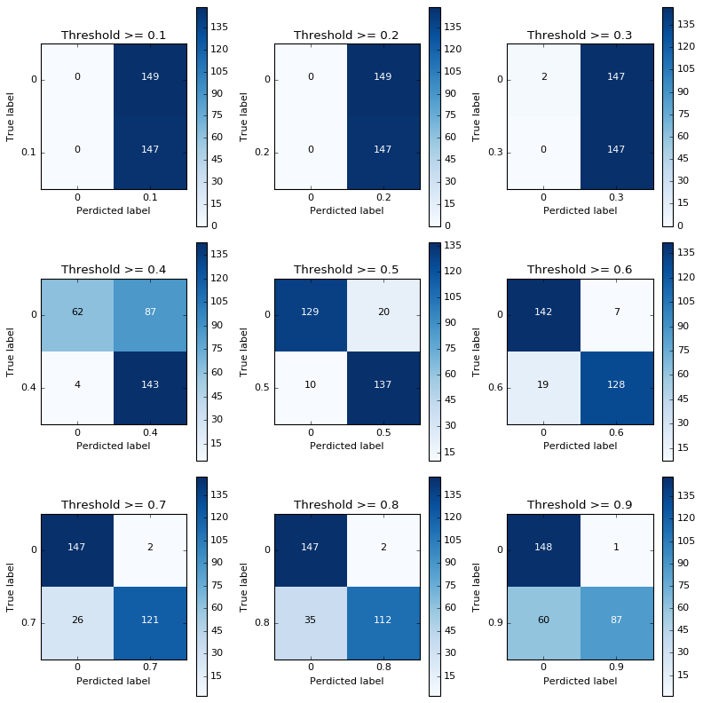

```python
lr = LogisticRegression(C = 0.01, penalty='l1')
lr.fit(X_train_undersample, y_train_undersample.values.ravel())
y_pred_undersample_proba = lr.predict_proba(X_test_undersample.values)

# 设置不同的阈值
thresholds = [0.1, 0.2, 0.3, 0.4, 0.5, 0.6, 0.7, 0.8, 0.9]

plt.figure(figsize=(10, 10))

j = 1
for i in thresholds:
    y_test_undersample_high_recall = y_pred_undersample_proba[:, 1] > i

    plt.subplot(3, 3, j)
    j += 1

    # Compute confusion matrix
    cnf_matrix = confusion_matrix(y_test_undersample, y_test_undersample_high_recall)
    np.set_printoptions(precision=2)

    print('Recal metric in the testing dataset: ', cnf_matrix[1, 1] / (cnf_matrix[1, 0] + cnf_matrix[1, 1]))

    # Plot non-normalized confusion matrix
    class_names = [0, i]
    plot_confusion_matrix(cnf_matrix,
                      classes=class_names,
                      title='Threshold >= %s' %i)
```

### 过采样 — SMOTE样本生成策略

- 对于少数类中每一个样本x, 以欧氏距离为标准计算它到少数类样本集中所有样本的距离，得到其k近邻。
- 根据样本不平衡比例设置一个采样比例以确定采样倍率N，对于每一个少数类样本x, 从其k近邻中随机选择若干样本，假设选择的近邻为 xn。
- 对于每一个随机选出的近邻 xn, 分别与原样本按照如下的公式构建新的样本。
- $X_{new} = X + rand(0, 1) \times 欧式距离$

```python
import pandas as pd
from imblearn.over_sampling import SMOTE
from sklearn.ensemble import RandomForestClassifier
from sklearn.metrics import confusion_matrix
from sklearn.model_selection import train_test_split
```

```python
credit_cards = pd.read_csv('creditcard.csv')

columns = credit_cards.columns
# The labels are in the last column ('Class'), Simply remove it to obtain features cloumns
features_columns = columns.delete(len(columns) - 1)

features = credit_cards[features_columns]
labels = credit_cards['Class']
```

```python
features_train, features_test, labels_train, labels_test = train_test_split(features,
                                                                            labels,
                                                                            test_size=0.2,
                                                                            random_state=0)
```

```python
oversampler = SMOTE(random_state=0)
os_features, os_labels = oversampler.fit_sample(features_train, labels_train)
```

```python
len(os_labels[os_labels == 1])
```

```
227454
```

```python
os_features = pd.DataFrame(os_features)
os_labels = pd.DataFrame(os_labels)
best_c = printing_Kfold_score(os_features, os_labels)
```

[output not shown]

```
Recall metric in the testing dataset:  0.910891089109
```

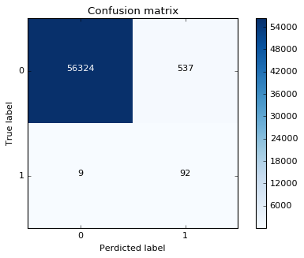

```python
lr = LogisticRegression(C = best_c, penalty='l1')
lr.fit(os_features, os_labels.values.ravel())
y_pred = lr.predict(features_test.values)


# Compute confusion matrix
cnf_matrix = confusion_matrix(labels_test, y_pred)
np.set_printoptions(precision=2)

print("Recall metric in the testing dataset: ", cnf_matrix[1, 1] / (cnf_matrix[1, 0] + cnf_matrix[1, 1]))

# Plot non-nonmalized confusion matrix
class_names = [0, 1]
plt.figure()
plot_confusion_matrix(cnf_matrix, classes = class_names,
                      title = 'Confusion matrix')
plt.show()
```

#### 过采样--> Recal 低一些，模型整体的精度更高一些

- 精度 = (TP + TN) / Total